# Beating the booky with xgBoost [1]

Tobias Diederich

18 März 2016

Beating the booky in prediction performance is an ambitious goal. Odds calculating companies (further refered to as bookys) put a huge effort in calculating accurate probabilities. I expect them to have large statistic branches with a lot of manual predicting support from sport analysts. Never the less, there are conditions, which could be exploited to gain an advantage:  
1. Market behaviour: Bookys adjust their odds depending on market behaviour, which is expected to be irrational  
2. Feature variety: Using different kinds of features than bookies  
3. Domain limitation: Concentrating on German 1. Bundesliga

This blog is meant to be a continous story. In this first post I build a model with features, solely engineered from marketprices of participating players. In future work these features will be supplemented by shortterm form values for players, engineered from grades given by the famous german sportsmagazin ‘Kicker’. Additional preprocessing, dimension reduction and further modeling technics will be applied.  
To make a start, the modeling algorithm xgboost is used, because it is known to be high perfoming for different problems. Several winning solutions on kaggle used it.

## Goal

This work aims on implementing a model to predict accurate probabilities, which applied in a betting strategy against booky odds would simulate a preferably high percentage profit. This simulated percentage profit is implemented as a custom metric and integrated in carets model tuning process.

## Data

The match, team and player data are collected from [transfermarkt.de](http://www.transfermarkt.de/) and [kicker.de](http://www.kicker.de/). Booky odds are collected from [sfstats.net](http://de.sfstats.net/).

Relevant data will be of germanies 1. Bundesliga for seasons 2005-2015.

```r
source(file = '../dataProvider/loadData.R', echo = FALSE, encoding = 'UTF-8')
toMatchday <- 34
seasons <- c('2005-2006', '2006-2007', '2007-2008', '2008-2009', '2009-2010',
             '2010-2011', '2011-2012', '2012-2013', '2013-2014', '2014-2015')
leagues <- c('BL1')
data <- loadTrainingData(toMatchday, seasons, leagues, dbName = 'soccerlabdata')
matches <- data$matches
odds <- data$odds
stats <- data$stats
```

- matches: Matches for Germanies 1. Bundesliga for seasons 2005-2015
- odds: Booky odds and probabilies for all matches
- stats: Player - match data, including played position, actual marketprice and kicker grade, the player got for his performance

There are 3060 matches and 109552 related player - match data.

```r
# Summary of marketprices
summary(stats$fitPrice)
```

```
##     Min.  1st Qu.   Median     Mean  3rd Qu.     Max.     NA's
##        0  1000000  2400000  4021000  4500000 55000000      333
```

### Remarks on booky odds

The bookies probability of a match outcome is the odds reciproke. For a match their probabilities do not sum up to 1, but to a value above 1. This is a booky margin, the main cause they make money and a big disadvantage for the punter. This margin decreases the payout in comparison to a fair bet.

Booky margin statistics:

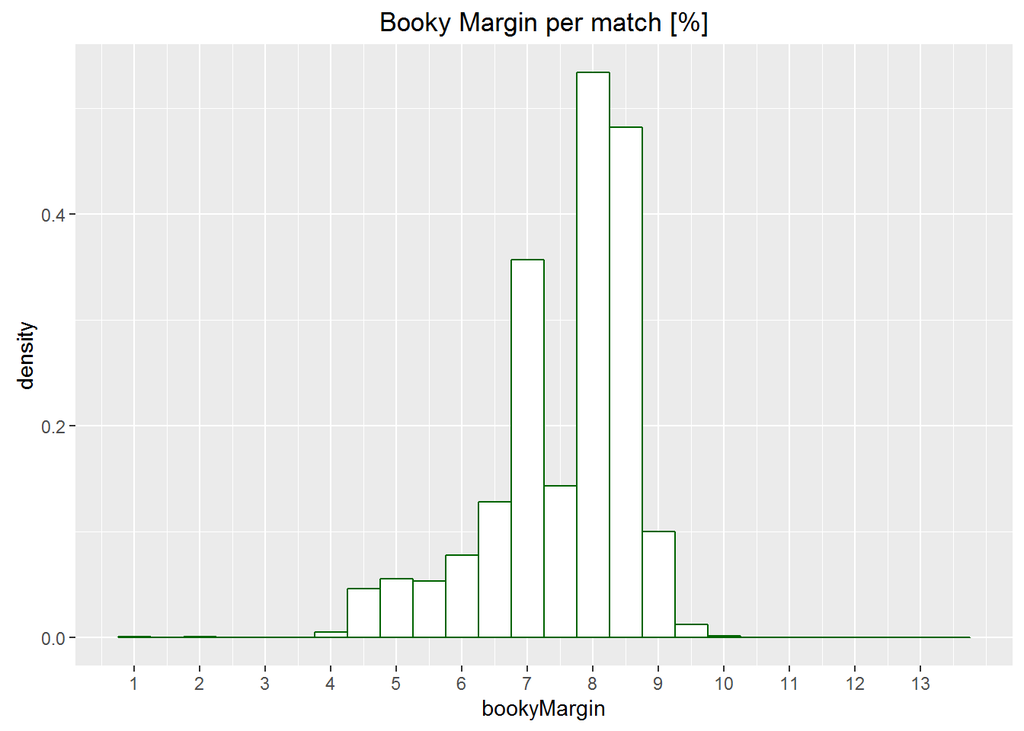

```r
exploreOdds <- mutate(odds, bookyMargin =
                          (HomeVictory + VisitorsVictory + Draw - 1) * 100)
# 13 matches have incorrect values -> bookyProbSum < 1
exploreOdds <- filter(exploreOdds, bookyMargin >= 0)
ggplot(exploreOdds, aes(x = bookyMargin)) +
    geom_histogram(aes(y=..density..),
                   binwidth=.5,
                   colour="darkgreen", fill="white") +
    scale_x_continuous(breaks = round(seq(min(exploreOdds$bookyMargin), max(exploreOdds$bookyMargin), by = 1), 0)) +
  ggtitle('Booky Margin per match [%]')
```

## Feature Engineering

The engineered features solely correspond to the marketprices of players. All players in the starting lineup are taken into consideration. The players on bench participate in specially dedicated features. The prices are grouped by Position (tw, def, mid, off), Team (Home, Visitors) and aggregation Function (min, max, avg, sum).

```r
source(file = '../featureEngineering/positionFeatureExtraction.R', echo = FALSE, encoding = 'UTF-8')
assignedPositions <- c('tw', 'def', 'def', 'def', 'mid', 'mid', 'mid',
                       'mid', 'off', 'off', 'off', 'off', 'off')
relNormalAssignments <- c('DURCHGESPIELT', 'AUSGEWECHSELT')
priceFuncts <- c('min', 'max', 'avg', 'sum')
benchPriceFuncts <- c('max', 'avg')
priceFeaturedMatches <- extractMatchResultFeatures(stats, matches, assignedPositions, relNormalAssignments, priceFuncts = priceFuncts, benchPriceFuncts = benchPriceFuncts)

features <- priceFeaturedMatches[, grepl('Price', colnames(priceFeaturedMatches))]
```

Some features for bench players and for position tw (Torwart = goaly) are left out, because they don’t add much value.

So we have 38 features.

### Feature correlation

Let’s explore the features in comparison to each other. For the sake of overview I select just the features for home teams.

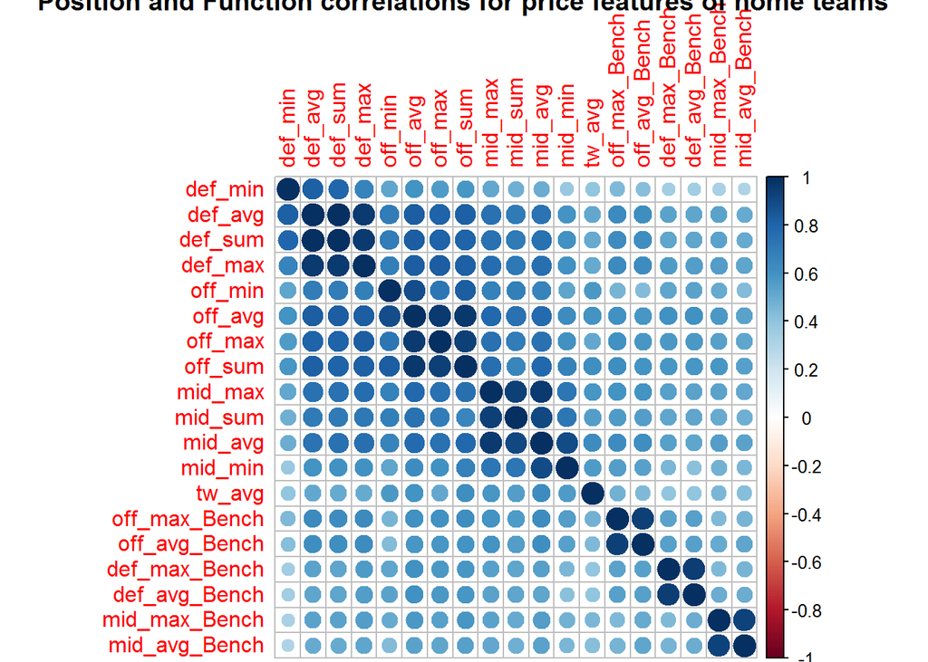

```r
# Position and Function correlation for price features of home teams
priceHomeData <- features[, grepl('Home', colnames(features))]
colnames(priceHomeData) <- gsub('_Price', '', gsub('_Home', '', colnames(priceHomeData)))
priceCorrData <- cor(priceHomeData)
corrplot(priceCorrData, order = 'AOE',
         title = 'Position and Function correlations for price features of home teams')
```

=> All sum - features and all Bench - avg - features will be removed, because they are highly correlated with other features.

## Model fitting and tuning

The target of the model tuning process is to find a model which maximizes the simulated profit [%]. This is a custom metric and implemented in the function betMetricsSummary. This function is integrated in the caret resampling and tuning process (caret is so great!!). I did some prework to find areas of parameter values which tend to give good results. Here, just the fine tuning is done. The applied model is extreme gradient boosting, a popular algorithm which is known to have very good and stable predictive performance in various different cases. Additionally it has a lot of fine tuning potential and supports parallel processing.

### Configuration of the fitting process

```r
source(file = '../models/models.R',
       echo = FALSE, encoding = 'UTF-8')
modelInput <- selectModelInput(priceFeaturedMatches)
# Reduce highly correlated features
modelInput <- reducePriceFeatures(modelInput)

seed <- 16450
customCvContr <- trainControl(method = 'cv', number = 5, classProbs = TRUE,
                              summaryFunction = betMetricsSummary)

resultFormula <- as.formula('matchResult ~ . -matchId -goalsHome -goalsVisitors -goalDiff')
```

### Extreme Gradiant Boosing

Tuning Parameters:  
- nrounds (# Boosting Iterations)  
- max_depth (Max Tree Depth)  
- eta (Shrinkage)  
- gamma (Minimum Loss Reduction)  
- colsample_bytree (Subsample Ratio of Columns)  
- min_child_weight (Minimum Sum of Instance Weight)

```r
# Set tuning parameter sets #
extrBoostGrid <- expand.grid(nrounds = 50 + (1:5)*50,
                             max_depth = c(4, 5),
                             eta = c(.1),
                             gamma = c(0),
                             colsample_bytree = 1,
                             min_child_weight = 1)

set.seed(seed)
priceXGBoostModel <- train(form = resultFormula, data = modelInput,
                           method = 'xgbTree', trControl = customCvContr,
                           tuneGrid = extrBoostGrid, metric = 'GainPerc',
                           objective = 'multi:softprob', num_class = 3,
                           allowParallel = TRUE)
```

# Results

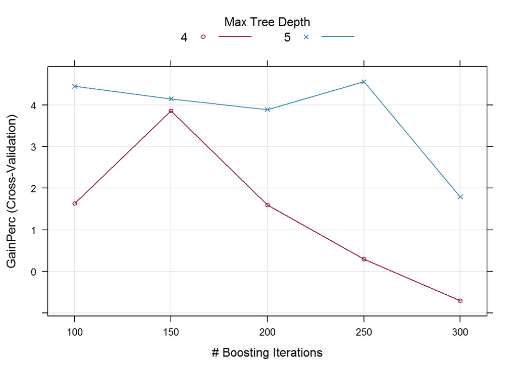

```r
results <- priceXGBoostModel$results[as.integer(rownames(
  priceXGBoostModel$results)) == as.integer(rownames(priceXGBoostModel$bestTune)), ]

# Tuning Profile
trellis.par.set(caretTheme())
plot(priceXGBoostModel)
```

```r
# Non-resampled training performance
testPred <- predict(priceXGBoostModel, modelInput)
confMatrix <- confusionMatrix(testPred, reference = modelInput$matchResult)
confMatrix$overall
```

```
##       Accuracy          Kappa  AccuracyLower  AccuracyUpper   AccuracyNull
##   9.790850e-01   9.674595e-01   9.733696e-01   9.838565e-01   4.509804e-01
## AccuracyPValue  McnemarPValue
##   0.000000e+00   4.788736e-07
```

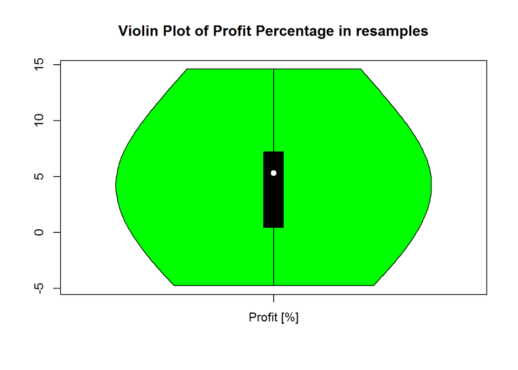

```r
vioplot(priceXGBoostModel$resample$GainPerc, names = 'Profit [%]', col = 'green')
title('Violin Plot of Profit Percentage in resamples')
```

```r
summary(priceXGBoostModel$resample$GainPerc)
```

```
##    Min. 1st Qu.  Median    Mean 3rd Qu.    Max.
## -4.7610  0.4342  5.3120  4.5560  7.1930 14.6000
```

For comparison I use two bet strategy benchmarks:  
1. Allways bet on home  
2. Pick one bet on a random outcome, each game

```r
inputData <- data.frame(rowIndex = modelInput$matchId, obs = modelInput$matchResult)
homeVictorybenchmarkData <- fillByAllHomeBenchmark(inputData)
level <- c('VisitorsVictory', 'Draw', 'HomeVictory')
model <- 'HomeVictory Benchmark'
homeVictoryBenchmark <- betMetricsSummary(homeVictorybenchmarkData, level, model)
homeVictoryBenchmark
```

```
##      Accuracy         Kappa BookyAccuracy    BookyKappa      GainPerc
##     0.4509804     0.0000000     0.5075163     0.1676227    -6.8895444
## ValueDiffPerc
##     1.9267926
```

```r
set.seed(seed)
randomBenchmarkData <- fillByAllRandom(inputData)
model <- 'Random Benchmark'
randomBenchmark <- betMetricsSummary(randomBenchmarkData, level, model)
randomBenchmark
```

```
##      Accuracy         Kappa BookyAccuracy    BookyKappa      GainPerc
##    0.39705882    0.01352931    0.50751634    0.16762273   -2.33659731
## ValueDiffPerc
##   -9.67281679
```

Both metrics result in poor shape as expected.

# Conclusions and Forecast